# Enrichment Analysis of differentially expressed genes

last changed: 2023-08-29

# Enrichment Analysis

## Data processing

First, the rlog transformed data is required.

```r
> dss.RNAseq <- readRDS(file = "./../Significance_testing/Data/rlog_RNAseq_sig.rds")
> head(dss.RNAseq)
```

```
## class: DESeqTransform
## dim: 6 9
## metadata(1): version
## assays(1): ''
## rownames(6): ENSG00000187961 ENSG00000187583 ... ENSG00000158286
##   ENSG00000049249
## rowData names(7): baseMean baseVar ... dispFit rlogIntercept
## colnames(9): Exp1_0h Exp1_05h ... Exp1_4h Exp2_4h
## colData names(6): ID name ... Time sizeFactor
```

```r
> rlog.RNAseq <- assay(dss.RNAseq)
> head(rlog.RNAseq)
```

```
##                   Exp1_0h  Exp1_05h  Exp2_05h   Exp1_1h   Exp2_1h   Exp1_2h
## ENSG00000187961  9.472383  9.401083  9.549674  9.371890  9.375284  9.284801
## ENSG00000187583  6.887230  6.870783  6.890566  6.874117  6.849387  6.806578
## ENSG00000272512  3.451118  3.511433  3.459465  3.485438  3.484753  3.580382
## ENSG00000157933 10.105359 10.170151 10.091244 10.161497 10.127752 10.401630
## ENSG00000158286  6.990695  6.898103  6.873236  6.832657  6.817953  6.681328
## ENSG00000049249  6.356913  6.406154  6.435095  6.505523  6.303375  6.637583
##                   Exp2_2h   Exp1_4h   Exp2_4h
## ENSG00000187961  9.351290  9.207517  9.297696
## ENSG00000187583  6.800197  6.624615  6.704975
## ENSG00000272512  3.525865  3.624321  3.594942
## ENSG00000157933 10.414798 10.408695 10.438903
## ENSG00000158286  6.754343  6.572696  6.712422
## ENSG00000049249  6.686996  6.670499  6.582007
```

```r
> info.RNAseq <- data.frame(colData(dss.RNAseq))
> paged_table(info.RNAseq)
```

|  | ID | name | condition | replica | Time | sizeFactor |
| --- | --- | --- | --- | --- | --- | --- |
| Exp1_0h | Exp1_0 | Exp1_0 | 0hpi | R1 | 0.0 | 1.0908519 |
| Exp1_05h | Exp1_05h | Exp1_05h | 0.5hpi | R1 | 0.5 | 0.8861148 |
| Exp2_05h | Exp2_05h | Exp2_05h | 0.5hpi | R2 | 0.5 | 0.8545649 |
| Exp1_1h | Exp1_1h | Exp1_1h | 1hpi | R1 | 1.0 | 0.9294310 |
| Exp2_1h | Exp2_1h | Exp2_1h | 1hpi | R2 | 1.0 | 2.8920422 |
| Exp1_2h | Exp1_2h | Exp1_2h | 2hpi | R1 | 2.0 | 0.9800447 |
| Exp2_2h | Exp2_2h | Exp2_2h | 2hpi | R2 | 2.0 | 1.0280833 |
| Exp1_4h | Exp1_4h | Exp1_4h | 4hpi | R1 | 4.0 | 0.6642453 |
| Exp2_4h | Exp2_4h | Exp2_4h | 4hpi | R2 | 4.0 | 0.6961808 |

Next, the data was separated into the corresponding clustering. Furthermore, the required gene IDs for the following enrichment analyses were added.

```r
> # load clustering
> kmeans.k4 <- readRDS("./../Clustering/Data/kmeans.rds")
> lapply(kmeans.k4, head)
```

```
## $cluster
## ENSG00000187961 ENSG00000187583 ENSG00000272512 ENSG00000157933 ENSG00000158286
##               3               2               4               4               3
## ENSG00000049249
##               4
##
## $centers
##      Exp1_0h   Exp1_05h   Exp2_05h    Exp1_1h    Exp2_1h     Exp1_2h    Exp2_2h
## 1 -0.8421754 -0.8041345 -0.2961166 -0.6527848 -0.4332373  0.18206277  0.1051941
## 2  0.9034335  0.9517914  0.1183134  0.6508920  0.3836864 -0.06174722 -0.2085434
## 3  0.8034308  0.5416800  1.1006731  0.2855925  0.7122827 -0.58521197 -0.4817977
## 4 -0.8300726 -0.5902684 -1.0351506 -0.5131713 -0.6840032  0.65723077  0.7167958
##     Exp1_4h    Exp2_4h
## 1  1.765050  0.9761413
## 2 -1.657416 -1.0804106
## 3 -1.301679 -1.0749710
## 4  0.993705  1.2849346
##
## $totss
## [1] 9182.267
##
## $withinss
## [1] 563.6810 455.3611 425.9889 581.3837
##
## $tot.withinss
## [1] 2026.415
##
## $betweenss
## [1] 7155.852
##
## $size
## [1] 308 263 232 369
##
## $iter
## [1] 2
##
## $ifault
## [1] 0
```

```r
> clus.kmeans <- melt(kmeans.k4$cluster)
> clus.kmeans <- cbind(clus.kmeans, 1:nrow(clus.kmeans))
> colnames(clus.kmeans) <- c("cluster", "ind")
> clus.kmeans <- clus.kmeans[order(clus.kmeans[, "cluster"]), ]
> paged_table(clus.kmeans)
```

|  | cluster | ind |
| --- | --- | --- |
| ENSG00000116685 | 1 | 8 |
| ENSG00000186501 | 1 | 18 |
| ENSG00000130772 | 1 | 21 |
| ENSG00000162419 | 1 | 22 |
| ENSG00000196182 | 1 | 29 |
| ENSG00000066135 | 1 | 37 |
| ENSG00000117425 | 1 | 39 |
| ENSG00000159588 | 1 | 42 |
| ENSG00000162396 | 1 | 45 |
| ENSG00000162616 | 1 | 52 |

[output cut: 1162 more lines]

```r
> # annotate genes to cluster as a list:
> ind.cluster1 <- clus.kmeans[which(clus.kmeans[, "cluster"] == 1), "ind"]
> ind.cluster2 <- clus.kmeans[which(clus.kmeans[, "cluster"] == 2), "ind"]
> ind.cluster3 <- clus.kmeans[which(clus.kmeans[, "cluster"] == 3), "ind"]
> ind.cluster4 <- clus.kmeans[which(clus.kmeans[, "cluster"] == 4), "ind"]
>
> genes.k1 <- rlog.RNAseq[ind.cluster1, ] %>% rownames()
> genes.k2 <- rlog.RNAseq[ind.cluster2, ] %>% rownames()
> genes.k3 <- rlog.RNAseq[ind.cluster3, ] %>% rownames()
> genes.k4 <- rlog.RNAseq[ind.cluster4, ] %>% rownames()
>
> genes <- list("1" = genes.k1, "2" = genes.k2, "3" = genes.k3, "4" = genes.k4)
>
> saveRDS(genes, file = "./Data/RNAseq_genes_cluster.rds")
>
> # get correct gene IDs:
> genes.ID <- lapply(genes,
+                    bitr,
+                    fromType = "ENSEMBL",
+                    toType = "ENTREZID",
+                    OrgDb = "org.Hs.eg.db")
>
> ID <- lapply(genes.ID, function(x) x[, 2])
```

## Reactome pathway analysis enrichment analysis

Finally, the filtered list with the coding genes can be used for an enrichment analysis using the function `enrichPathway`, which can be plotted using `dotplot`.

```r
> PA.RNAseq <- compareCluster(geneCluster = ID,
+                                   fun = "enrichPathway",
+                                   pvalueCutoff = 0.05,
+                                   pAdjustMethod = "BH")
>
> PA.RNAseq %>% as.data.frame() %>% paged_table()
```

| Cluster | ID | Description | GeneRatio | BgRatio | pvalue | p.adjust | qvalue | geneID | Count |
| --- | --- | --- | --- | --- | --- | --- | --- | --- | --- |
| 1 | R-HSA-381119 | Unfolded Protein Response (UPR) | 10/162 | 94/10955 | 1.177703e-06 | 0.0006110614 | 0.0005602561 | 153222/4189/1968/84447/9709/118460/1054/2931/7494/468 | 10 |
| 1 | R-HSA-9648895 | Response of EIF2AK1 (HRI) to heme deficiency | 5/162 | 15/10955 | 1.771192e-06 | 0.0006110614 | 0.0005602561 | 1968/79094/1054/22809/468 | 5 |
| 1 | R-HSA-381042 | PERK regulates gene expression | 5/162 | 32/10955 | 9.692080e-05 | 0.0222917842 | 0.0204383865 | 1968/9709/118460/1054/468 | 5 |

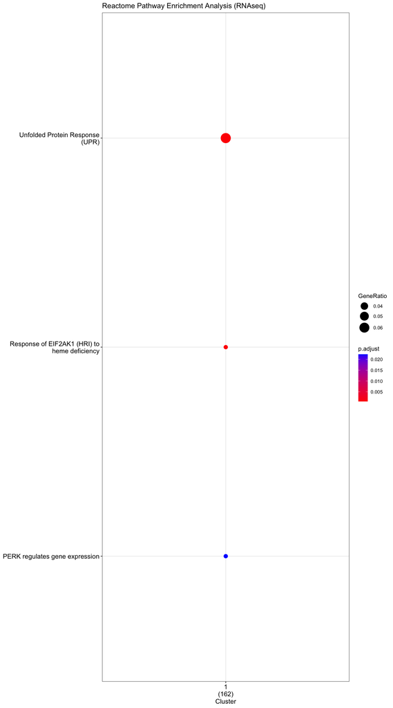

```r
> dotplot(PA.RNAseq, showCategory = 10,
+         title = "Reactome Pathway Enrichment Analysis (RNAseq)")
```

## Gene Ontology enrichment analysis

Exactly the same as above can be done with the function `enrichGO`.

```r
> GO.RNAseq <- compareCluster(geneCluster = ID,
+                                   fun = "enrichGO",
+                                   OrgDb = org.Hs.eg.db,
+                                   ont = "BP",
+                                   readable = T,
+                                   pvalueCutoff = 0.05,
+                                   pAdjustMethod = "BH")
>
> GO.RNAseq %>% as.data.frame() %>% paged_table()
```

| Cluster | ID | Description | GeneRatio | BgRatio | pvalue | p.adjust | qvalue | geneID | Count |
| --- | --- | --- | --- | --- | --- | --- | --- | --- | --- |
| 1 | GO:0035966 | response to topologically incorrect protein | 14/256 | 164/18614 | 6.407868e-08 | 0.0001316428 | 0.0001234048 | DNAJB4/NFE2L2/DNAJB2/CREBRF/STC2/HSPA1A/HSPA1B/DNAJB9/UBE2W/DNAJA1/CHAC1/HERPUD1/XBP1/ATF4 | 14 |
| 1 | GO:0006986 | response to unfolded protein | 13/256 | 142/18614 | 8.376887e-08 | 0.0001316428 | 0.0001234048 | DNAJB4/NFE2L2/DNAJB2/CREBRF/STC2/HSPA1A/HSPA1B/DNAJB9/DNAJA1/CHAC1/HERPUD1/XBP1/ATF4 | 13 |
| 1 | GO:0090084 | negative regulation of inclusion body assembly | 4/256 | 12/18614 | 1.586110e-05 | 0.0128887259 | 0.0120821689 | DNAJB2/HSPA1A/HSPA1B/DNAJB6 | 4 |
| 1 | GO:0097193 | intrinsic apoptotic signaling pathway | 15/256 | 301/18614 | 1.940609e-05 | 0.0128887259 | 0.0120821689 | NFE2L2/MSX1/ZNF622/HSPA1A/CDKN1A/DNAJA1/SYVN1/DDIT4/COA8/CHAC1/RRN3/HERPUD1/PMAIP1/XBP1/ATF4 | 15 |
| 1 | GO:0009408 | response to heat | 9/256 | 110/18614 | 2.120451e-05 | 0.0128887259 | 0.0120821689 | DNAJB4/IER5/SLU7/HSPA1A/HSPA1B/ASIC3/DNAJB6/DNAJA1/TRPV1 | 9 |
| 1 | GO:0070059 | intrinsic apoptotic signaling pathway in response to endoplasmic reticulum stress | 7/256 | 63/18614 | 2.460463e-05 | 0.0128887259 | 0.0120821689 | HSPA1A/SYVN1/CHAC1/HERPUD1/PMAIP1/XBP1/ATF4 | 7 |
| 1 | GO:0035967 | cellular response to topologically incorrect protein | 9/256 | 118/18614 | 3.711898e-05 | 0.0166664240 | 0.0156234643 | NFE2L2/STC2/HSPA1A/HSPA1B/DNAJB9/UBE2W/HERPUD1/XBP1/ATF4 | 9 |
| 1 | GO:0032436 | positive regulation of proteasomal ubiquitin-dependent protein catabolic process | 8/256 | 93/18614 | 4.264690e-05 | 0.0167549000 | 0.0157064036 | NFE2L2/DNAJB2/CSNK1A1/HSPA1A/HSPA1B/HERPUD1/AURKA/GSK3A | 8 |
| 1 | GO:0034620 | cellular response to unfolded protein | 8/256 | 98/18614 | 6.212369e-05 | 0.0216949722 | 0.0203373335 | NFE2L2/STC2/HSPA1A/HSPA1B/DNAJB9/HERPUD1/XBP1/ATF4 | 8 |
| 1 | GO:1902235 | regulation of endoplasmic reticulum stress-induced intrinsic apoptotic signaling pathway | 5/256 | 32/18614 | 7.032755e-05 | 0.0221039495 | 0.0207207176 | HSPA1A/SYVN1/HERPUD1/PMAIP1/XBP1 | 5 |

[output cut: 30 more lines]

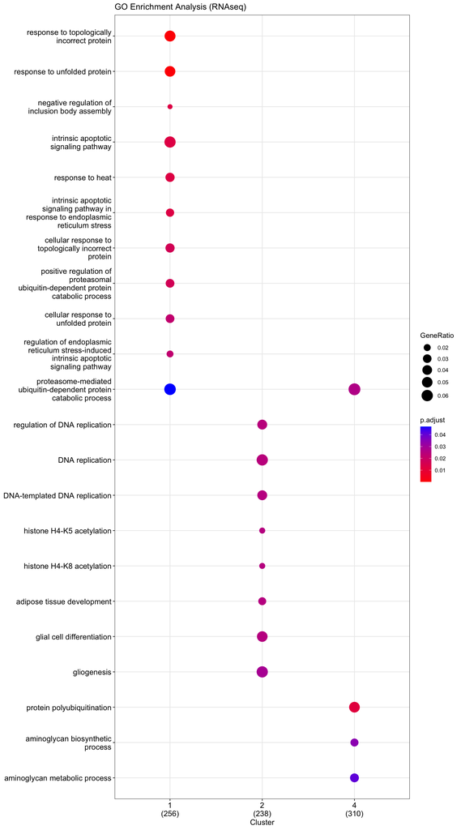

```r
> dotplot(GO.RNAseq, showCategory = 10,
+         title = "GO Enrichment Analysis (RNAseq)")
```

## References - packages

- Ahlmann-Eltze C, Hickey P, Pagès H (2023). *MatrixGenerics: S4 Generic Summary Statistic Functions that Operate on Matrix-Like Objects*. doi:10.18129/B9.bioc.MatrixGenerics https://doi.org/10.18129/B9.bioc.MatrixGenerics, R package version 1.12.2, https://bioconductor.org/packages/MatrixGenerics.
- Allaire J, Xie Y, Dervieux C, McPherson J, Luraschi J, Ushey K, Atkins A, Wickham H, Cheng J, Chang W, Iannone R (2023). *rmarkdown: Dynamic Documents for R*. R package version 2.23, https://github.com/rstudio/rmarkdown. Xie Y, Allaire J, Grolemund G (2018). *R Markdown: The Definitive Guide*. Chapman and Hall/CRC, Boca Raton, Florida. ISBN 9781138359338, https://bookdown.org/yihui/rmarkdown. Xie Y, Dervieux C, Riederer E (2020). *R Markdown Cookbook*. Chapman and Hall/CRC, Boca Raton, Florida. ISBN 9780367563837, https://bookdown.org/yihui/rmarkdown-cookbook.
- Arora S, Morgan M, Carlson M, Pagès H (2023). *GenomeInfoDb: Utilities for manipulating chromosome names, including modifying them to follow a particular naming style*. doi:10.18129/B9.bioc.GenomeInfoDb https://doi.org/10.18129/B9.bioc.GenomeInfoDb, R package version 1.36.0, https://bioconductor.org/packages/GenomeInfoDb.
- Bengtsson H (2023). *matrixStats: Functions that Apply to Rows and Columns of Matrices (and to Vectors)*. R package version 1.0.0, https://CRAN.R-project.org/package=matrixStats.
- Carlson M (2023). *org.Hs.eg.db: Genome wide annotation for Human*. R package version 3.17.0.
- Huber W, Carey VJ, Gentleman R, Anders S, Carlson M, Carvalho BS, Bravo HC, Davis S, Gatto L, Girke T, Gottardo R, Hahne F, Hansen KD, Irizarry RA, Lawrence M, Love MI, MacDonald J, Obenchain V, Ole’s AK, Pag`es H, Reyes A, Shannon P, Smyth GK, Tenenbaum D, Waldron L, Morgan M (2015). “Orchestrating high-throughput genomic analysis with Bioconductor.” *Nature Methods*, *12*(2), 115-121. http://www.nature.com/nmeth/journal/v12/n2/full/nmeth.3252.html.
- Huber, W., Carey, J. V, Gentleman, R., Anders, S., Carlson, M., Carvalho, S. B, Bravo, C. H, Davis, S., Gatto, L., Girke, T., Gottardo, R., Hahne, F., Hansen, D. K, Irizarry, A. R, Lawrence, M., Love, I. M, MacDonald, J., Obenchain, V., Ole’s, K. A, Pag`es, H., Reyes, A., Shannon, P., Smyth, K. G, Tenenbaum, D., Waldron, L., Morgan, M. (2015). “Orchestrating high-throughput genomic analysis with Bioconductor.” *Nature Methods*, *12*(2), 115-121. http://www.nature.com/nmeth/journal/v12/n2/full/nmeth.3252.html.
- Lawrence M, Huber W, Pagès H, Aboyoun P, Carlson M, Gentleman R, Morgan M, Carey V (2013). “Software for Computing and Annotating Genomic Ranges.” *PLoS Computational Biology*, *9*. doi:10.1371/journal.pcbi.1003118 https://doi.org/10.1371/journal.pcbi.1003118, http://www.ploscompbiol.org/article/info%3Adoi%2F10.1371%2Fjournal.pcbi.1003118.
- Lawrence M, Huber W, Pagès H, Aboyoun P, Carlson M, Gentleman R, Morgan M, Carey V (2013). “Software for Computing and Annotating Genomic Ranges.” *PLoS Computational Biology*, *9*. doi:10.1371/journal.pcbi.1003118 https://doi.org/10.1371/journal.pcbi.1003118, http://www.ploscompbiol.org/article/info%3Adoi%2F10.1371%2Fjournal.pcbi.1003118.
- Lawrence M, Huber W, Pagès H, Aboyoun P, Carlson M, Gentleman R, Morgan M, Carey V (2013). “Software for Computing and Annotating Genomic Ranges.” *PLoS Computational Biology*, *9*. doi:10.1371/journal.pcbi.1003118 https://doi.org/10.1371/journal.pcbi.1003118, http://www.ploscompbiol.org/article/info%3Adoi%2F10.1371%2Fjournal.pcbi.1003118.
- Love MI, Huber W, Anders S (2014). “Moderated estimation of fold change and dispersion for RNA-seq data with DESeq2.” *Genome Biology*, *15*, 550. doi:10.1186/s13059-014-0550-8 https://doi.org/10.1186/s13059-014-0550-8.
- Makowski D, Lüdecke D, Patil I, Thériault R, Ben-Shachar M, Wiernik B (2023). “Automated Results Reporting as a Practical Tool to Improve Reproducibility and Methodological Best Practices Adoption.” *CRAN*. https://easystats.github.io/report/.
- Morgan M, Obenchain V, Hester J, Pagès H (2023). *SummarizedExperiment: SummarizedExperiment container*. doi:10.18129/B9.bioc.SummarizedExperiment https://doi.org/10.18129/B9.bioc.SummarizedExperiment, R package version 1.30.2, https://bioconductor.org/packages/SummarizedExperiment.
- Pagès H, Carlson M, Falcon S, Li N (2023). *AnnotationDbi: Manipulation of SQLite-based annotations in Bioconductor*. doi:10.18129/B9.bioc.AnnotationDbi https://doi.org/10.18129/B9.bioc.AnnotationDbi, R package version 1.62.1, https://bioconductor.org/packages/AnnotationDbi.
- Pagès H, Lawrence M, Aboyoun P (2023). *S4Vectors: Foundation of vector-like and list-like containers in Bioconductor*. doi:10.18129/B9.bioc.S4Vectors https://doi.org/10.18129/B9.bioc.S4Vectors, R package version 0.38.1, https://bioconductor.org/packages/S4Vectors.
- R Core Team (2023). *R: A Language and Environment for Statistical Computing*. R Foundation for Statistical Computing, Vienna, Austria. https://www.R-project.org/.
- Wickham H (2007). “Reshaping Data with the reshape Package.” *Journal of Statistical Software*, *21*(12), 1-20. http://www.jstatsoft.org/v21/i12/.
- Wickham H, François R, Henry L, Müller K, Vaughan D (2023). *dplyr: A Grammar of Data Manipulation*. R package version 1.1.2, https://CRAN.R-project.org/package=dplyr.
- Wu T, Hu E, Xu S, Chen M, Guo P, Dai Z, Feng T, Zhou L, Tang W, Zhan L, Fu x, Liu S, Bo X, Yu G (2021). “clusterProfiler 4.0: A universal enrichment tool for interpreting omics data.” *The Innovation*, *2*(3), 100141. doi:10.1016/j.xinn.2021.100141 https://doi.org/10.1016/j.xinn.2021.100141. Yu G, Wang L, Han Y, He Q (2012). “clusterProfiler: an R package for comparing biological themes among gene clusters.” *OMICS: A Journal of Integrative Biology*, *16*(5), 284-287. doi:10.1089/omi.2011.0118 https://doi.org/10.1089/omi.2011.0118.
- Xie Y (2023). *knitr: A General-Purpose Package for Dynamic Report Generation in R*. R package version 1.43, https://yihui.org/knitr/. Xie Y (2015). *Dynamic Documents with R and knitr*, 2nd edition. Chapman and Hall/CRC, Boca Raton, Florida. ISBN 978-1498716963, https://yihui.org/knitr/. Xie Y (2014). “knitr: A Comprehensive Tool for Reproducible Research in R.” In Stodden V, Leisch F, Peng RD (eds.), *Implementing Reproducible Computational Research*. Chapman and Hall/CRC. ISBN 978-1466561595.
- Yu G, He Q (2016). “ReactomePA: an R/Bioconductor package for reactome pathway analysis and visualization.” *Molecular BioSystems*, *12*(12), 477-479. doi:10.1039/C5MB00663E https://doi.org/10.1039/C5MB00663E, http://pubs.rsc.org/en/Content/ArticleLanding/2015/MB/C5MB00663E.